# Glucocorticoid receptor dynamica

# Introduction

Inflammation is an essential process of the immune system to encounter offending agents. However, in some diseases this results in extreme symptoms which may be dangerous or sometimes even life-threatening. To regulate inflammation the body uses glucocorticoids (GC), which are a type of steroid hormones that represses inflammation. This anti-inflammatory function of GC is activated by binding of the GCs to the GC receptors (GR), forming GC-GR complexes. These complexes bind to different genes, resulting in both its anti-inflammatory function it is known for and inhibition of the GR mRNA synthesis. To get insight in this process and the effect of the variables, the process can be modelled [1].

This activation and repression of genes is achieved by binding to GR, which are found in the cytoplasm. When a GC binds to a GR, it is activated. This activation results in the translocation of this GC-GR complex to the nucleus [1][4][5]. Once in the nucleus, the complex can bind to the GC response element (GRE) in the promoter region of the different genes [1]. Most of these genes are then activated and provide anti-inflammatory products, such as chemokines and cytokines [6]. However, the GC-GR complex also binds to the GRE in the GR gene. This binding supresses the mRNA transcription [1].

Since the GR represses its own mRNA synthesis, it may not always be effective to add more GCs. To get an understanding of the system and its variables, a model can be made. Various simulations are performed in this research to see how this may effect the system as a whole.

# Method

The glucocorticoid receptor dynamics is described by a flow diagram and differential equations. The different parameters and variables are explained and there is an overview of their values for a basic scenario.

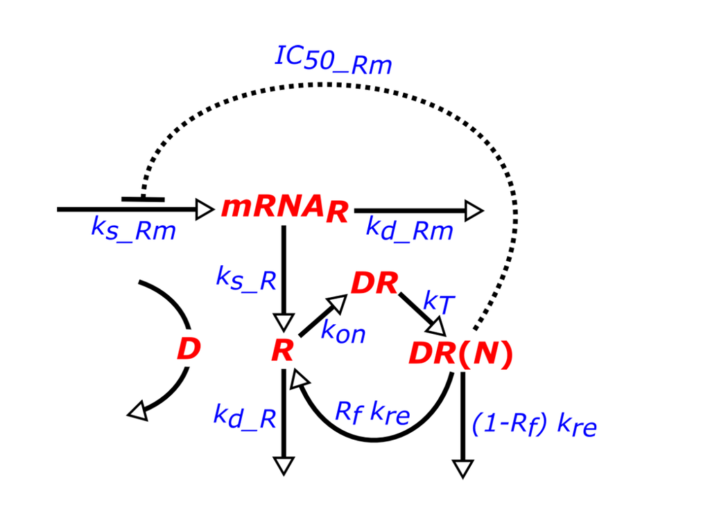

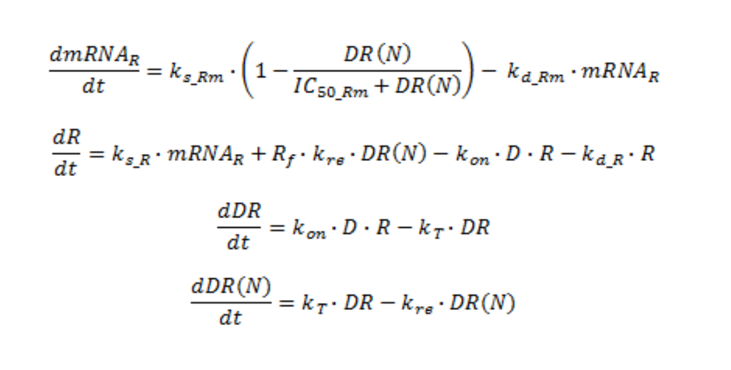

Here, D is the plasma concentration of MPL, mRNAR the quantity of receptor mRNA, R the density of glucocorticoide receptor in the cytosol, DR the density of the MPL-receptor complex and DR(N) the quantity of the MPL-receptor complex in the nucleus. Ks_Rm is the zero order rate constant of mRNA synthesis and kd_Rm the first order rate constant of mRNA degradation. Ks_R and kd_R are the first order rate constant of respectively the synthesis and degradation of the receptor. KT is the first order rate constant for the translocation of the MPL-receptor complex to the nucleus and kre is the first order rate constant for the transport of the receptor from the nucleus to the cytosol. Kon is the second order rate constant for the formation of the MPL-receptor complex. Rf is the fraction free receptor that is recycled and IC_50Rm is the concentration DR(N) where the synthesis of receptor mRNA decreases till 50% of the initial value.

### Parameters and values

Here follow the parameters and values used in the model, these are the values for the basic scenario.

| Parameter | Value |
| --- | --- |
| ks_Rm (fmol/g liver/h) | 2.90 |
| IC50_Rm (fmol/mg protein) | 26.2 |
| kon (L/nmol/h) | 0.00329 |
| kT (1 / h) | 0.63 |
| kre (1 / h) | 0.57 |
| Rf | 0.49 |
| kd_R (1 / h) | 0.0572 |
| kd_Rm | 0.612 |
| ks_r | 3.22 |
| D (nmol/L) | 53.4086752 |

### Initial values

Here follow the initial values of the variables, these are the values for the basic scenario.

| Variables | Value |
| --- | --- |
| mRNAR (fmol / g liver) | 4.74 |
| R (fmol/mg protein) | 267 |
| DR (fmol/mg protein) | 0 |
| DR(N) (fmol/mg protein) | 0 |

# Results

First, data from an experiment is compared with simulation data, to asses model validity. Then results of a change in the model or modelparameters are compared to the basic scenario.

## Assess model validity

To asses model validity, data from experimental data for two doses are compared with the simulation data. In the experiment MPL was administered for 7 days under constant infusion of 0.1 or 0.3 mg drug/kg rat/h. The concentration of the drug, receptor mRNA and the free receptor were measured.

### Dependence of the results on the dose and concentration of the drug

The model variables mRNA and R are compared with the experimental data by running simulations and adjusting dosis D.

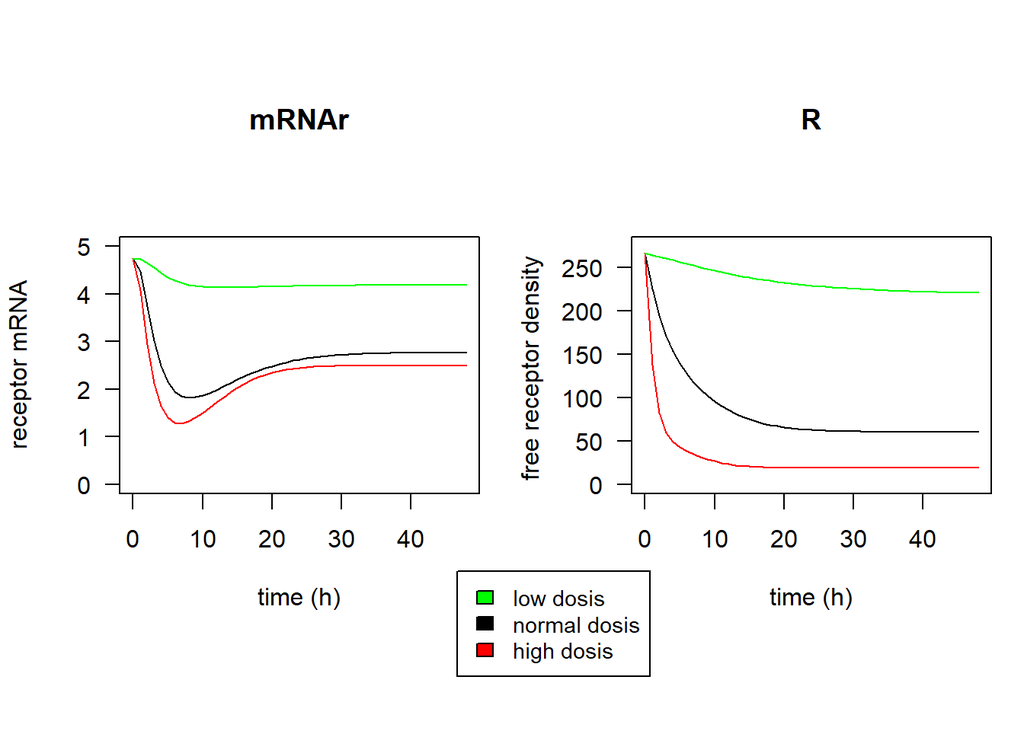

```r
# Load deSolve package
library(deSolve)

# Function with the models differential equations
corticosteroid <- function(t, state, paramters) {
  with(as.list(c(state, paramters)),{
    dmRNAr <- ks.Rm * (1 - DR.N / (IC50.Rm + DR.N)) - k.dRm * mRNAr

    dR <- k.sR * mRNAr + Rf * k.re * DR.N - k.on * D * R - k.dR * R

    dDR <- k.on * D * R - k.T * DR

    dDR.N <- k.T * DR - k.re * DR.N

    list(c(dmRNAr, dR, dDR, dDR.N))
  })
}

# Parameters
parameters <- c(ks.Rm = 2.90,
                IC50.Rm = 26.2,
                k.on = 0.00329,
                k.T = 0.63,
                k.re = 0.57,
                Rf = 0.49,
                k.dR = 0.0572,
                k.dRm = 0.612,
                k.sR = 3.22,
                D = 20 * 1000 * 1/374.471 )

# Initial values
state<- c(mRNAr = 4.74,
           R = 267,
           DR = 0,
           DR.N = 0)

# Time frame of 2 days
times <- seq(0, 48)

out.normal <- ode(y = state, times = times, func = corticosteroid, parms = parameters)

# Increase medicine dose and simulate it
parameters['D'] <- 80 * 1000 * 1/374.471
out.high <- ode(y = state, times = times, func = corticosteroid, parms = parameters)

#Decrease medicine dose and simulate it
parameters['D'] <- 1 * 1000 * 1/374.471
out.low <- ode(y = state, times = times, func = corticosteroid, parms = parameters)

# Create two plots in one figure
par(mfrow = c(1,2), mar = c(8.1, 4.1, 8.1, 1.1))

# mRNAr plot
plot(out.normal[,1], out.normal[,2], las = 1, main = "mRNAr", ylim = c(0, 5), type = "l",
     xlab = "time (h)", ylab = "receptor mRNA")
lines(out.high[,2] ~ out.normal[,1], col = "red")
lines(out.low[,2] ~ out.normal[,1], col = "green")

# R plot
plot(out.normal[,1], out.normal[,3], las = 1, main = "R", ylim = c(0, 275), type = "l",
     xlab = "time (h)", ylab = "free receptor density ")
lines(out.high[,3] ~ out.normal[,1], col = "red")
lines(out.low[,3] ~ out.normal[,1], col = "green")

# Add legend
legend(x = -27, y = -100, legend = c("low dosis", "normal dosis", "high dosis"), fill = c("green", "black", "red"), cex = 0.9, xpd=NA)
```

- mRNAr  
  The concentration of mRNAr is influenced by the MPL concentration. When a lower MPL concentration is used the mRNAr is decreasing slower. The DR(N) affects the mRNAr synthesis, this DR(N) concentration is lower when there is less MPL and therefore the mRNAr does not decrease as much. When a higher dosis is used the mRNAr is decreasing more rapidly and a lower end concentration at equilibrium can be seen. This is becuase the medicine can bind to more receptors, which results in more DR and therefore more DR(N). The IC50 value is reached earlier and the mRNAr concentration gets decreased.
- R  
  The R concentration decreases less when using a lower MPL concentration. This is due to the fact that there is less MPL to create a MPL-receptor complex, so the R concentration stays high. The opposite can be seen when using a higher MPL concentration. The receptor concentration decreases very fast and has a lower end concentration. This is because there is more medicine to bind to the receptor, resulting in a lower receptor concentration.

### Model results vs experimental data

To see if the model results are inline with the experimental data, a mRNA plot is made. Here it is easy to compare the model (black line) with the experiment (datapoint). The median (red line) is also in the plot because the median is less sensitive for possible outliers. If a certain value is very high or very low this does not affect the value of the median. When compared to the mean, for example, this does get affected by an outlier.

```r
MPL <- read.csv("MPL.csv")
```

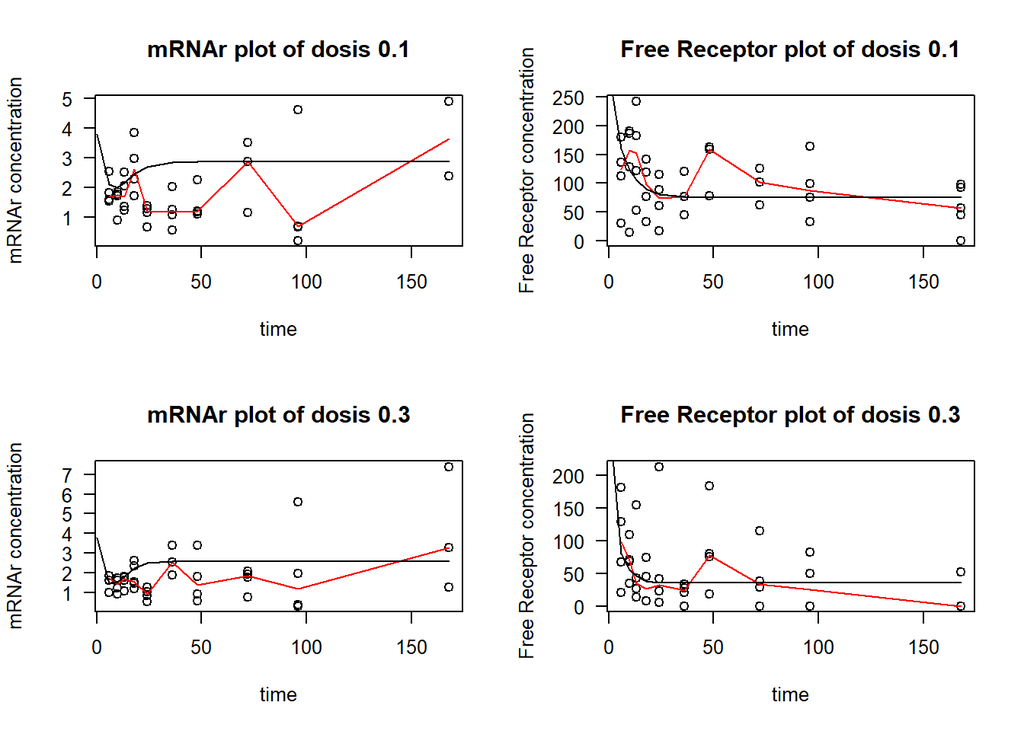

```r
# Get experimental data for different doses
dose.0.1 <- MPL[MPL$dose == 0.1,]
dose.0.3 <- MPL[MPL$dose == 0.3,]

# Get medians
medians <- aggregate(MPL[,c("MPL_conc","mRNA","Free_receptor")],list(MPL$dose,MPL$time), median, na.rm=T)
names(medians)[1:2] <- c("dose","time")

# Get medians per dosis
median.0.1 <- medians[medians$dose == 0.1,]
median.0.3 <- medians[medians$dose == 0.3,]

# Changes states of model from medians on time = 0
state['mRNAr'] <- medians[medians$time == 0,]$mRNA
state['R'] <- medians[medians$time == 0,]$Free_receptor

# Change the duration of the model with time points from experimental data
times <- unique(MPL$time)

# Change dosis concentration parameter (D) for 0.1 dosis
median_MPL_01 <- median(MPL$MPL_conc[MPL$dose==0.1], na.rm=T)
parameters['D'] <- median_MPL_01 * 1000 * 1/374.471

# Simulate model for 0.1 dosis
out.0.1 <- ode(y = state, times = times, func = corticosteroid, parms = parameters)

# Change dosis concentration parameter (D) for 0.3 dosis
median_MPL_03 <- median(MPL$MPL_conc[MPL$dose==0.3], na.rm=T)
parameters['D'] <- median_MPL_03 * 1000 * 1/374.471

# Simulate model for 0.3 dosis
out.0.3 <- ode(y = state, times = times, func = corticosteroid, parms = parameters)

par(mfrow = c(2,2), cex = 0.8)

# Plot mRNA plot for 0.1 dose
plot(dose.0.1$mRNA ~ dose.0.1$time,
     xlab = "time", ylab = "mRNAr concentration", main = "mRNAr plot of dosis 0.1", las =1)
points(median.0.1$mRNA ~ median.0.1$time, col = "red", type = "l")
lines(out.0.1[,1], out.0.1[,2])

# Plot Free Receptor points for 0.1 dose
plot(dose.0.1$Free_receptor ~ dose.0.1$time,
     xlab = "time", ylab = "Free Receptor concentration", main = "Free Receptor plot of dosis 0.1", las = 1)
points(median.0.1$Free_receptor ~ median.0.1$time, col = "red", type = "l")
lines(out.0.1[,1], out.0.1[,3])

# Plot mRNA plot for 0.3 dose
plot(dose.0.3$mRNA ~ dose.0.3$time,
     xlab = "time", ylab = "mRNAr concentration", main = "mRNAr plot of dosis 0.3", las =1 )
points(median.0.3$mRNA ~ median.0.3$time, col = "red", type = "l")
lines(out.0.3[,1], out.0.3[,2])

# Plot Free Receptor points for 0.3 dose
plot(dose.0.3$Free_receptor ~ dose.0.3$time,
     xlab = "time", ylab = "Free Receptor concentration", main = "Free Receptor plot of dosis 0.3", las = 1)
points(median.0.3$Free_receptor ~ median.0.3$time, col = "red", type = "l")
lines(out.0.3[,1], out.0.3[,3])
```

The results of the model are not in line with experimental data, but this differs between the plots. The free receptor plots (both doses) are somewhat similar of that of the model, except for one outlier at a time of 50. The mRNAr plots show way less similarities, where the experimental line fluctuates a lot.

This may be caused by the structure of the data. Firstly, the data is divided in a strange way. In the beginning there are a lot datapoints and at a higher time less. Secondly, there are not many datapoints per time unit to reliable fit the data. Lastly, the experimental data may contain some bias due to measurement errors or other factors that can influence the concentration of mRNAr or free receptor.

## Simulate scenario’s

Here different scenarios are simulated to see what happends if the model and model parameters are changed, the results are compared to the basic scenario.

### No auto-regulation of glucocorticoid receptor

Here the time course concentration of the activated drug-receptor complex is plotted if there was no effect of drug on the synthesis of the receptor mRNA. The first formula has to be changed, because DR(N) has an effect on the synthesis of the receptor mRNA.

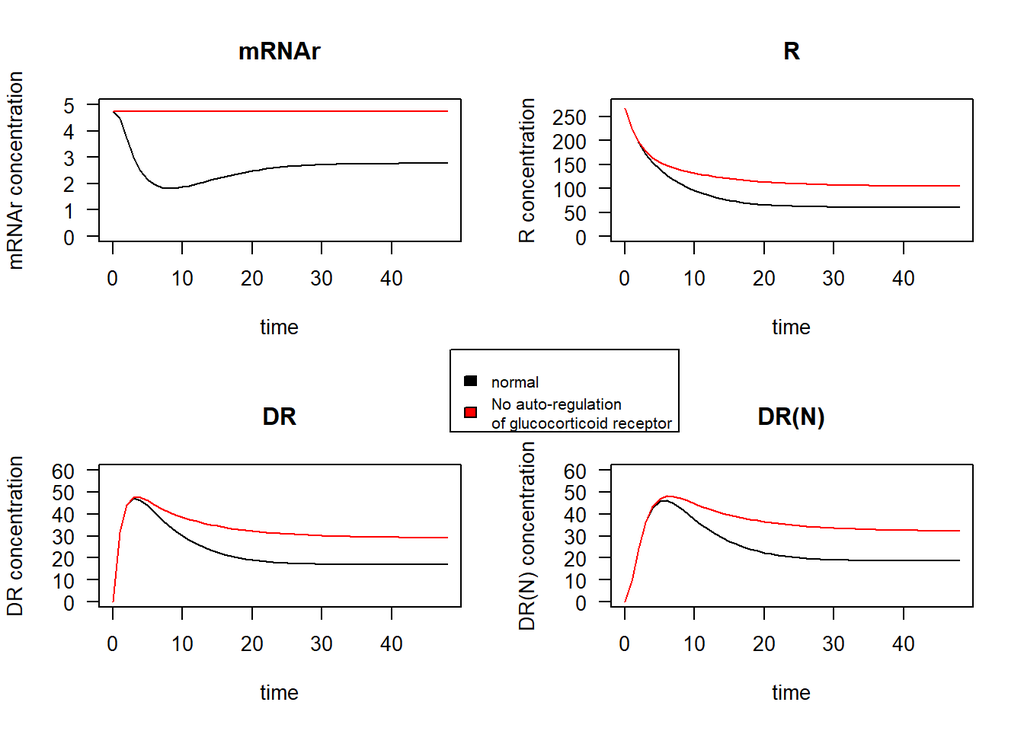

```r
# New function with changed formula
corticosteroid.changed <- function(t, state, parameters) {
  with(as.list(c(state, parameters)),{
    dmRNAr <- ks.Rm * (1 - DR.N * 0 / (IC50.Rm + DR.N * 0)) - k.dRm * mRNAr

    dR <- k.sR * mRNAr + Rf * k.re * DR.N - k.on * D * R - k.dR * R

    dDR <- k.on * D * R - k.T * DR

    dDR.N <- k.T * DR - k.re * DR.N

    list(c(dmRNAr, dR, dDR, dDR.N))
  })
}

# Parameter values
parameters <- c(ks.Rm = 2.90,
                IC50.Rm = 26.2,
                k.on = 0.00329,
                k.T = 0.63,
                k.re = 0.57,
                Rf = 0.49,
                k.dR = 0.0572,
                k.dRm = 0.612,
                k.sR = 3.22,
                D = 20 * 1000 * 1/374.471 )

# Initial state
state <- c(mRNAr = 4.74,
           R = 267,
           DR = 0,
           DR.N = 0)

# Time frame for 2 days
times <- seq(0, 48)

# Simulate model with changed formula
out.changed <- ode(y = state, times = times, func = corticosteroid.changed, parms = parameters)

# Multiple plots in one figure
par(mfrow = c(2,2))

# Plot mRNAr concentration
plot(out.normal[,2] ~ out.normal[,1], las = 1, type = "l", ylab = "mRNAr concentration", xlab = "time", main = "mRNAr", ylim = c(0,5))
lines(out.changed[,2] ~ out.changed[,1], col= "red")

# Plot R concentration
plot(out.normal[,3] ~ out.normal[,1], las = 1, type = "l", ylab = "R concentration", xlab = "time", main = "R",
     ylim = c(0, 275))
lines(out.changed[,3] ~ out.changed[,1], col = "red")

# Plot DR
plot(out.normal[,4] ~ out.normal[,1], las = 1, type = "l", ylab = "DR concentration", xlab = "time", main = "DR", ylim = c(0,60))
lines(out.changed[,4] ~ out.changed[,1], col = "red")

# Plot DR(N)
plot(out.normal[,5] ~ out.normal[,1], las = 1,type = "l", ylab = "DR(N) concentration", xlab = "time", main = "DR(N)", ylim = c(0,60))
lines(out.changed[,5] ~ out.changed[,1], col = "red")

# Add legend
legend(x = -25, y = 115, legend = c("normal", "No auto-regulation \nof glucocorticoid receptor"),
       fill = c("black", "red"), xpd = NA, cex = 0.8)
```

When there is no auto-regulation of glucocorticoid receptor, the mRNAr concentration stays steady at the initial value. This is because DR(N) does not inhibit the sythesis of mRNAr. So mRNAr makes receptors, the mRNAr concentration decrease, but also new mRNAr is synthesized, the mRNAr concentration increases. this leads to a steady concentration of mRNAr and a higher concentration of receptor. This also leads to more medicine-receptor complexes in the cytosol (DR) and nucleus (DR(N)).

### Drug treatment is stopped

The time course of receptor and mRNA concentrations is plotted when the drug treatment is stopped. So After the steady state is reached, D is set to zero and the simulation continues till the new steady state is reached.

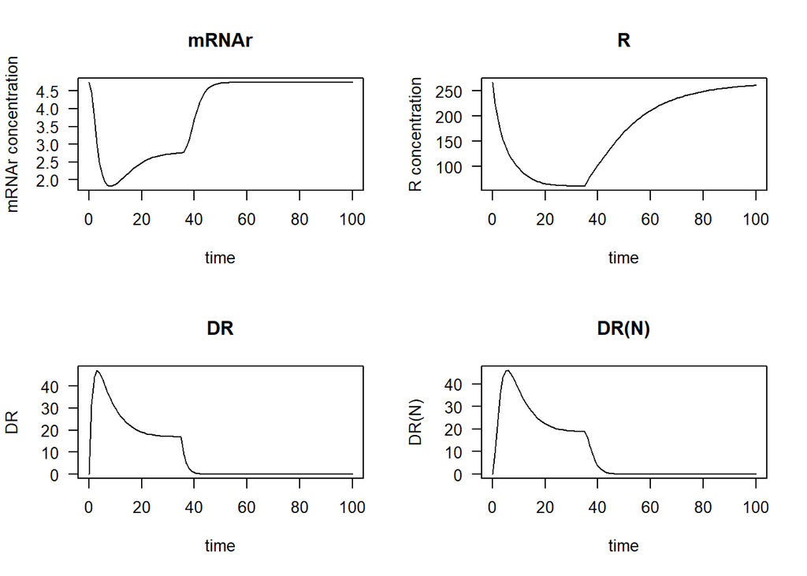

```r
# Parameter values
parameters <- c(ks.Rm = 2.90,
                IC50.Rm = 26.2,
                k.on = 0.00329,
                k.T = 0.63,
                k.re = 0.57,
                Rf = 0.49,
                k.dR = 0.0572,
                k.dRm = 0.612,
                k.sR = 3.22,
                D = 20 * 1000 * 1/374.471 )

# Initial values
state <- c(mRNAr = 4.74,
           R = 267,
           DR = 0,
           DR.N = 0)

# Time frame until first steady state and till second steady state
t.steady <- seq(0, 35)
t.steady.second <- seq(35, 100)

# Simulate model for basic scenario
out.steady <- ode(y = state, times = t.steady, func = corticosteroid, parms = parameters)

# Simulate model for when drug treatment has stopped
parameters['D'] <- 0
out.steady.second <- ode(y = tail(out.steady, 1)[,-1], times = t.steady.second, func = corticosteroid, parms = parameters)

# Multiple plots in one figure
par(mfrow = c(2,2))

# Plot mRNAr concentration
plot(out.steady[,2] ~ out.steady[,1], las = 1, xlim = c(0, 100), type = "l", ylab = "mRNAr concentration", xlab = "time", main = "mRNAr")
lines( out.steady.second[,2] ~ out.steady.second[,1])

# Plot R concentration
plot(out.steady[,3] ~ out.steady[,1], las = 1, xlim = c(0, 100), type = "l", ylab = "R concentration", xlab = "time", main = "R")
lines( out.steady.second[,3] ~ out.steady.second[,1])

# Plot DR
plot(out.steady[,4] ~ out.steady[,1], las = 1, xlim = c(0, 100), type = "l", ylab = "DR", xlab = "time", main = "DR")
lines( out.steady.second[,4] ~ out.steady.second[,1])

# Plot DR(N)
plot(out.steady[,5] ~ out.steady[,1], las = 1, xlim = c(0, 100), type = "l", ylab = "DR(N)", xlab = "time", main = "DR(N)")
lines( out.steady.second[,5] ~ out.steady.second[,1])
```

We see that the mRNAr and R concentration first decrease a lot, because there is drug present. And then reaches a steady state, then when the drug treatment is stopped, the mRNAr and receptor concentration increase back to the initial value. This is because medicine-receptor complexes are no longer made, and the synthesis of mRNAr is no longer inhibited.

### Different association and dissociation rates from receptors

Different corticosteroids show different association rates from receptors (kon) and different dissociation rates (in this model reflected by kre). The same concentrations of the drug is assumed and the effect of different values of kon and kre (consider 2 and 5 times increase and decrease of both parameters separately) on the receptor and mRNA dynamics is plotted. kon and kre are adjusted as below and plot the results of the simulation for each change. Simulations are run for 4 new values of kon: 0.00329/5, 0.00329/2, 0.00329*2 and 0.003291*5. The results are compared to the basic scenario when kon=0.00329 Separately, simulations are run for 4 new values of kre: 0.57/5, 0.57/2, 0.57*2 and 0.57*5. The results should are compared to the basic scenario when kre= 0.57

```r
# Parameter values
parameters <- c(ks.Rm = 2.90,
                IC50.Rm = 26.2,
                k.on = 0.00329,
                k.T = 0.63,
                k.re = 0.57,
                Rf = 0.49,
                k.dR = 0.0572,
                k.dRm = 0.612,
                k.sR = 3.22,
                D = 20 * 1000 * 1/374.471 )

# Initial state
state <- c(mRNAr = 4.74,
           R = 267,
           DR = 0,
           DR.N = 0)

# Time frame for 2 days
t.steady <- seq(0, 48)

# Simulate different scenarios
kon.normal <- ode(y = state, times = t.steady, func = corticosteroid, parms = parameters)
parameters['k.on'] <- 0.00329 * 2
kon.increase2 <- ode(y = state, times = t.steady, func = corticosteroid, parms = parameters)
parameters['k.on'] <- 0.00329 * 5
kon.incerease5 <- ode(y = state, times = t.steady, func = corticosteroid, parms = parameters)
parameters['k.on'] <- 0.00329 / 2
kon.decrease2 <- ode(y = state, times = t.steady, func = corticosteroid, parms = parameters)
parameters['k.on'] <- 0.00329 / 5
kon.decrease5 <- ode(y = state, times = t.steady, func = corticosteroid, parms = parameters)


parameters['k.on'] <- 0.00329

kre.normal <- ode(y = state, times = t.steady, func = corticosteroid, parms = parameters)
parameters['k.re'] <- 0.57 * 2
kre.increase2 <- ode(y = state, times = t.steady, func = corticosteroid, parms = parameters)
parameters['k.re'] <- 0.57 * 5
kre.incerease5 <- ode(y = state, times = t.steady, func = corticosteroid, parms = parameters)
parameters['k.re'] <- 0.57 / 2
kre.decrease2 <- ode(y = state, times = t.steady, func = corticosteroid, parms = parameters)
parameters['k.re'] <- 0.57 / 5
kre.decrease5 <- ode(y = state, times = t.steady, func = corticosteroid, parms = parameters)
```

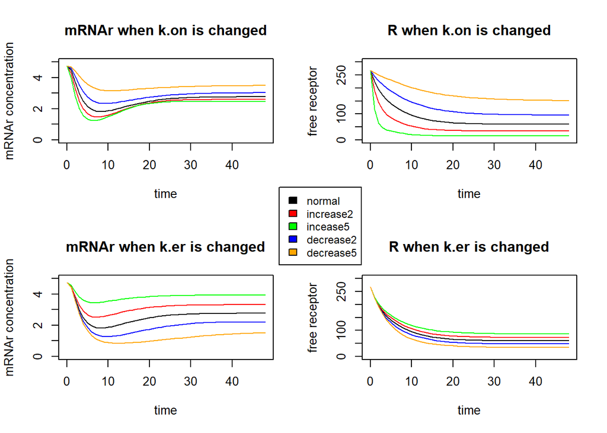

```r
# Multiple plots in one figure
par(mfrow = c(2,2))

# Plot scenarios for mRNAr concentration
plot(kon.normal[,2] ~ kon.normal[,1], type = 'l', ylim = c(0, 5),
     xlab = "time", ylab = "mRNAr concentration", main = "mRNAr when k.on is changed")
lines(kon.increase2[,2]~ kon.normal[,1], col = 'red')
lines(kon.incerease5[,2]~ kon.normal[,1], col = 'green')
lines(kon.decrease2[,2]~ kon.normal[,1], col = 'blue')
lines(kon.decrease5[,2]~ kon.normal[,1], col = "orange")

# Plot scenarios for R concentration
plot(kon.normal[,3] ~ kon.normal[,1], type = 'l',ylim = c(0, 300),
     xlab = "time", ylab = "free receptor", main = "R when k.on is changed")
lines(kon.increase2[,3]~ kon.normal[,1], col = 'red')
lines(kon.incerease5[,3]~ kon.normal[,1], col = 'green')
lines(kon.decrease2[,3]~ kon.normal[,1], col = 'blue')
lines(kon.decrease5[,3]~ kon.normal[,1], col = "orange")

# Plot scenarios for mRNAr concentration
plot(kre.normal[,2] ~ kon.normal[,1], type = 'l', ylim = c(0, 5),
     xlab = "time", ylab = "mRNAr concentration", main = "mRNAr when k.er is changed")
lines(kre.increase2[,2]~ kon.normal[,1], col = 'red')
lines(kre.incerease5[,2]~ kon.normal[,1], col = 'green')
lines(kre.decrease2[,2]~ kon.normal[,1], col = 'blue')
lines(kre.decrease5[,2]~ kon.normal[,1], col = "orange")

# Plot scenarios for R concentration
plot(kre.normal[,3] ~ kon.normal[,1], type = 'l',ylim = c(0, 300),
     xlab = "time", ylab = "free receptor", main = "R when k.er is changed")
lines(kre.increase2[,3]~ kon.normal[,1], col = 'red')
lines(kre.incerease5[,3]~ kon.normal[,1], col = 'green')
lines(kre.decrease2[,3]~ kon.normal[,1], col = 'blue')
lines(kre.decrease5[,3]~ kon.normal[,1], col = "orange")

# Add legend
legend(x = -22, y = 650, legend = c("normal", "increase2", "incease5", "decrease2", "decrease5"),
       fill = c("black", "red", "green", "blue", "orange"), xpd = NA, cex = 0.9)
```

k.on is the rate of the formation of the medicine-receptor complex  
k.er is the rate of the translocation of the receptor from the nucleus to the cytosol

- mRNAr when k.on is changed  
  When the k.on rate is increased, the mRNAr concentration decreases because k.on causes an increase in medicine-receptor complexes, which in turn increases more medicine-receptor complexes in the nucleus. And this increases leads to reaching faster of the IC50 value, which lowers the mRNAr synthesis. When the k.on rate is decreased, the mRNAr concentration increases because a lower k.on causes an decrease in medicine-receptor complexes, which in turn decreases the amount of medicine-receptor complexes in the nucleus. And this decrease leads to reaching of the IC50 value slower, which increases the mRNAr synthesis.
- mRNAr when k.er is changed  
  When the k.er is increased, the mRNAr concentration increases because the medicine-receptor concentration decreases in the nucleus, which leads to a slower reaching of the IC50 value. If the IC50 is reached slower, the mRNAr synthesis is higher. When the k.er is decreased, the mRNAr concentration decreases because the medicine-receptor concentration increases in the nucleus, which leads to a facter reaching of the IC50 value. If the IC50 is reached faster, the mRNAr synthesis is inhibited.
- R when k.on is changed  
  When the k.on rate is increased, the R concentration decreases because more medicine-receptor complexes are being formed. When the k.on is decrease, the R concentration increases because less medicine-receptor are being fomred.
- R when k.er is changed  
  When the k.er rate is increases, the R concentration increases because more receptors are being translocated from the nucleus to the cytosol. When the k.er rate is decreased, the R concentration decreases because less receptort are being translocated from the nucleus to the cytosol.

### Sythesis of receptor is blocked completely

The ks_r parameter needs to be put to zero, because this is the rate of the receptor synthesis.

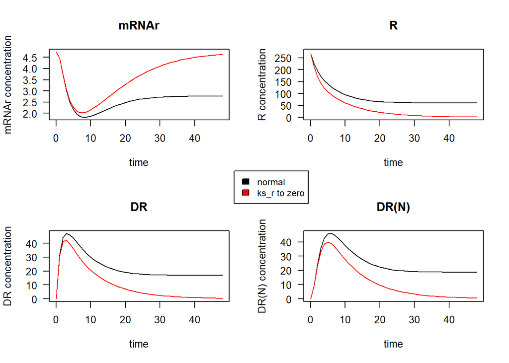

```r
# Parameter values
parameters <- c(ks.Rm = 2.90,
                IC50.Rm = 26.2,
                k.on = 0.00329,
                k.T = 0.63,
                k.re = 0.57,
                Rf = 0.49,
                k.dR = 0.0572,
                k.dRm = 0.612,
                k.sR = 3.22,
                D = 20 * 1000 * 1/374.471 )

# Initial values
state <- c(mRNAr = 4.74,
           R = 267,
           DR = 0,
           DR.N = 0)

# Timeframe for 2 days
t.steady <- seq(0, 48)

# Simulate scenario
out.normal <- ode(y = state, times = t.steady, func = corticosteroid, parms = parameters)
parameters['k.sR'] <- 0
out.ksr <- ode(y = state, times = t.steady, func = corticosteroid, parms = parameters)

# Multiple plots in one figure
par(mfrow = c(2,2))

# Plot mRNAr concentration
plot(out.normal[,2] ~ out.normal[,1], las = 1, type = "l", ylab = "mRNAr concentration", xlab = "time", main = "mRNAr")
lines(out.ksr[,2] ~ out.ksr[,1], col= "red")

# Plot R concentration
plot(out.normal[,3] ~ out.normal[,1], las = 1, type = "l", ylab = "R concentration", xlab = "time", main = "R",
     ylim = c(0, 275))
lines(out.ksr[,3] ~ out.ksr[,1], col = "red")

# Plot DR
plot(out.normal[,4] ~ out.normal[,1], las = 1, type = "l", ylab = "DR concentration", xlab = "time", main = "DR")
lines(out.ksr[,4] ~ out.ksr[,1], col = "red")

# Plot DR(N)
plot(out.normal[,5] ~ out.normal[,1], las = 1,type = "l", ylab = "DR(N) concentration", xlab = "time", main = "DR(N)")
lines(out.ksr[,5] ~ out.ksr[,1], col = "red")

# Add legend
legend(x = -22, y = 90, legend = c("normal", "ks_r to zero"),
       fill = c("black", "red"), xpd = NA, cex = 0.9)
```

(mRNAr is being discusses last)

- R  
  The Receptor concentration decreases, because no more receptor is being synthesised.
- DR  
  The medicine-receptor complex decreases, becuase no more receptors are available for the medicine to bind to form medicine-receptor complexes
- DR(N)  
  The nucleus medicine-receptor complex decreases, because the DR concentration also decreases. This also results in less medicine-receptor complexes in the nucleus
- mRNAr  
  The mRNAr concentration increases, when the receptor synthesis stops. This is because, as previously described, the DR(N) decreases. This will never reach the IC50 value, and therefore the mRNA synthesis is always ‘on’.

### Different rates of mRNAR production

The dynamic of the system is plotted when the baseline rate of production of mRNA of the receptor is increased or decreased 2 or 5 fold (recalculate the rate of mRNA degradation so that the steady-state assumption at baseline (without the drug) is still valid, i.e. mRNA levels are constant when there is not drug). ks_Rm values are changed, without the drug the system is at steady-state this means that kd_Rm = ks_Rm/mRNAr. Therefore if ks_Rm is changed, kd_Rm has to be changed as well. Simulations are run for 4 different scenarios:

- ks_Rm = 2.9/5 and kd_Rm=2.9/5/4.74
- ks_Rm = 2.9/2 and kd_Rm=2.9/2/4.74
- ks_Rm = 2.9*2 and kd_Rm=2.9*2/4.74
- ks_Rm = 2.9*5 and kd_Rm=2.9*5/4.74

```r
# Parameter values
parameters <- c(ks.Rm = 2.90,
                IC50.Rm = 26.2,
                k.on = 0.00329,
                k.T = 0.63,
                k.re = 0.57,
                Rf = 0.49,
                k.dR = 0.0572,
                k.dRm = 0.612,
                k.sR = 3.22,
                D = 20 * 1000 * 1/374.471 )

# Initial values
state <- c(mRNAr = 4.74,
           R = 267,
           DR = 0,
           DR.N = 0)

# Timeframe for 2 days
t.steady <- seq(0, 48)

# Simulate different scenarios
ksrm.normal <- ode(y = state, times = t.steady, func = corticosteroid, parms = parameters)
parameters['ks.Rm'] <- 2.90 * 2
parameters['k.dRm'] <- 2.90 * 2 / 4.74
ksrm.increase2 <- ode(y = state, times = t.steady, func = corticosteroid, parms = parameters)
parameters['ks.Rm'] <- 2.90 * 5
parameters['k.dRm'] <- 2.90 * 5 / 4.74
ksrm.incerease5 <- ode(y = state, times = t.steady, func = corticosteroid, parms = parameters)
parameters['ks.Rm'] <- 2.90 / 2
parameters['k.dRm'] <- 2.90 / 2 / 4.74
ksrm.decrease2 <- ode(y = state, times = t.steady, func = corticosteroid, parms = parameters)
parameters['ks.Rm'] <- 2.90 / 5
parameters['k.dRm'] <- 2.90 / 5 / 4.74
ksrm.decrease5 <- ode(y = state, times = t.steady, func = corticosteroid, parms = parameters)
```

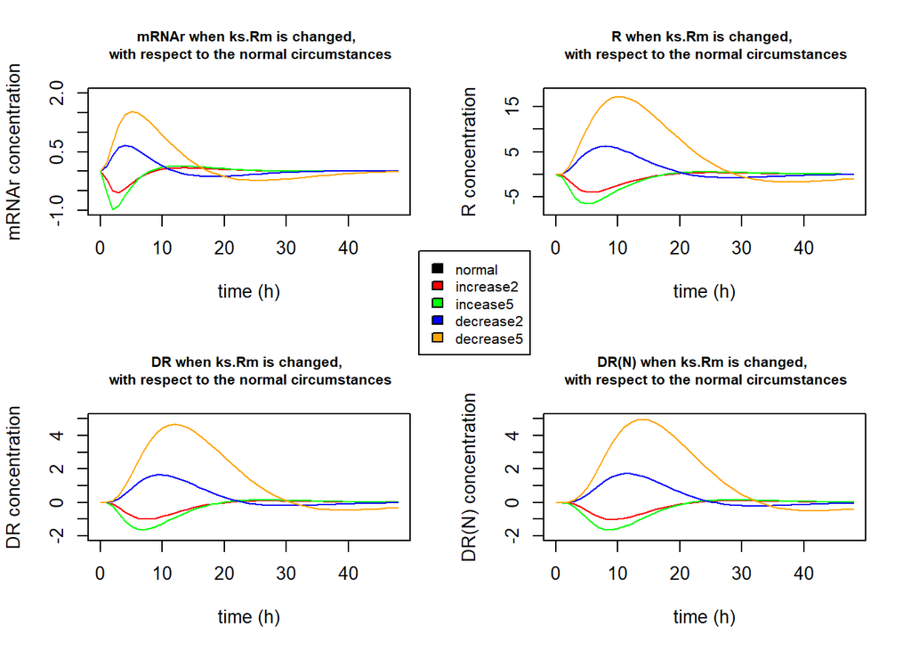

```r
# Multiple plots in one figure
par(mfrow = c(2, 2))

# Plot mRNAr concentration for scenarios
plot(ksrm.increase2[,2] - ksrm.normal[,2] ~ ksrm.normal[,1], col = 'red', type = 'l', ylim = c(-1, 2),
     xlab = "time (h)", ylab = "mRNAr concentration", main = "mRNAr when ks.Rm is changed, \n with respect to the normal circumstances", cex.main = 0.8)
lines(ksrm.incerease5[,2] - ksrm.normal[,2] ~ ksrm.normal[,1], col = 'green')
lines(ksrm.decrease2[,2] - ksrm.normal[,2] ~ ksrm.normal[,1], col = 'blue')
lines(ksrm.decrease5[,2] - ksrm.normal[,2] ~ ksrm.normal[,1], col = "orange")

# Plot R concentration dor scenarios
plot(ksrm.increase2[,3] - ksrm.normal[,3] ~ ksrm.normal[,1], col = 'red', type = 'l', ylim = c(-8, 18),
     xlab = "time (h)", ylab = "R concentration", main = "R when ks.Rm is changed, \n with respect to the normal circumstances", cex.main = 0.8)
lines(ksrm.incerease5[,3] - ksrm.normal[,3] ~ ksrm.normal[,1], col = 'green')
lines(ksrm.decrease2[,3] - ksrm.normal[,3] ~ ksrm.normal[,1], col = 'blue')
lines(ksrm.decrease5[,3] - ksrm.normal[,3] ~ ksrm.normal[,1], col = "orange")

# Plot DR for scenarios
plot(ksrm.increase2[,4] - ksrm.normal[,4] ~ ksrm.normal[,1], col = 'red', type = 'l', ylim = c(-2, 5),
     xlab = "time (h)", ylab = "DR concentration", main = "DR when ks.Rm is changed, \n with respect to the normal circumstances", cex.main = 0.8)
lines(ksrm.incerease5[,4] - ksrm.normal[,4] ~ ksrm.normal[,1], col = 'green')
lines(ksrm.decrease2[,4] - ksrm.normal[,4] ~ ksrm.normal[,1], col = 'blue')
lines(ksrm.decrease5[,4] - ksrm.normal[,4] ~ ksrm.normal[,1], col = "orange")

# Plot DR(N) for scenarios
plot(ksrm.increase2[,5] - ksrm.normal[,5] ~ ksrm.normal[,1], col = 'red', type = 'l', ylim = c(-2, 5),
     xlab = "time (h)", ylab = "DR(N) concentration", main = "DR(N) when ks.Rm is changed, \n with respect to the normal circumstances", cex.main = 0.8)
lines(ksrm.incerease5[,5] - ksrm.normal[,5] ~ ksrm.normal[,1], col = 'green')
lines(ksrm.decrease2[,5] - ksrm.normal[,5] ~ ksrm.normal[,1], col = 'blue')
lines(ksrm.decrease5[,5] - ksrm.normal[,5] ~ ksrm.normal[,1], col = "orange")

# Add legend
legend(x =-22, y = 15, legend = c("normal", "increase2", "incease5", "decrease2", "decrease5"),
       fill = c("black", "red", "green", "blue", "orange"), xpd = NA, cex = 0.8)
```

The graphs above are all with respect to the normal condition. This means that all of the graphs are substracted from the normal condition, and the graphs show the difference when compared to the normal condition.

- mRNAr  
  When there is a 2 or 5 fold decrease in ks.Rm, there is a lower rate synthesis of mRNAr. At the same time the rate of degradation also decreases, this leads to a higher mRNAr concentration. However, after some time the steady state (compared to the basic scenario) is reached, even though the rate of synthesis and degradation decreases. When there is a 2 or 5 fold increase in ks.rm, there is a higher rate of syntesis of mRNAr. At the same time the rate of degradation also increase, this leads to a lower mRNAr concentration. However, it appears as if the 2 or 5 fold increase doesn’t have a huge effect compared to the basic scenario. Furthermore after some time the same steady state has been reached.
- R  
  To continue the mRNAr discussion, the R concentration is directly influenced by the mRNAr concentration. So when there is a 2 or 5 fold decrease in synthesis and degradation rate of mRNAr, which leads to a higher mRNAr concentration, there is also more R. Similarly, when there is a 2 or 5 fold increase in synthesis and degradation rate of mRNAr, wich leads to a lower mRNAr concentration quicker, there is also a lower R concentration.
- DR  
  More R concentration leads to more medicine-receptor complexes, and a less R concentration leads to less medicine-receptor complexes.
- DR(N)  
  More medicine=receptor complexes will be transferred into the nucleus when there is a higher R concentration. However when there is a lower R concentration leads to less transportation of medicine-receptor complexes in the nucleus.

# References

[1] https://sci-hub.se/10.1111/j.1476-5381.2010.01199.x  
[2] https://link.springer.com/article/10.1007/s11154-007-9059-8  
[3] https://www.frontiersin.org/articles/10.3389/fimmu.2019.01545/full  
[4] https://www.sciencedirect.com/science/article/pii/S1521694211001537  
[5] https://www.sciencedirect.com/science/article/pii/S0167478104001794  
[6] https://link.springer.com/chapter/10.1007/164_2016_98

*References are not properly documented, this will be done correctly in the endreport*